# Classification of candidates in Brazilian elections

Binary Classification of candidates in previous Brazilian elections

José Benardi de Souza Nunes

01/12/2018

# Introduction

> Data Analysis and Classification on a subset of data about polls for the 2006 and 2010 elections in Brazil for the “Câmara Federal de Deputados”. Data was taken from the [TSE portal](http://www.tse.jus.br/) which originally encompassed approximately 7300 candidates.

# Data Overview

## The variables

```
The response variable is the variable that you are interested in reaching conclusions about.

A predictor variable is a variable used to predict another variable.

Our response variable will be "situacao", we want to study how well the predictor variables can help predict its behavior and how they impact in the linear regression.
```

#### Each item corresponds to a candidate, the attributes of each item are as follows:

- **ano** : Year at which the election took place.
- **sequencial_candidato** : Sequential ID to map the candidates
- **nome** : Name of the candidate
- **uf** : Federate state to which the candidate belongs.
- **partido** : Political party to which the candidate belongs.
- **quantidade_doacoes** : Number of donations received during political campaign.
- **quantidade_doadores** : Number of donors that contributed to the candidate’s political campaign.
- **total_receita** : Total revenue.
- **media_receita** : Mean revenue.
- **recursos_de_outros_candidatos.comites** : Revenue from other candidate’s committees.
- **recursos_de_pessoas_fisicas** : Revenue from individuals.
- **recursos_de_pessoas_juridicas** : Revenue from legal entities.
- **recursos_proprios** : Revenue from personal resources.
- **recursos_de_partido_politico** : Revenue from political party.
- **quantidade_despesas** : Number of expenses.
- **quantidade_fornecedores** : Number of suppliers.
- **total_despesa** : Total expenditure.
- **media_despesa** : Mean expenditure.
- **cargo** : Position.
- **sexo** : Sex.
- **grau** : Level of education.
- **estado_civil** : Marital status.
- **ocupacao** : Candidate’s occupation up to the election.
- **situacao** : Whether the candidate was elected.

## Loading Data

```r
readr::read_csv(here::here('data/train_class.csv'),
                progress = FALSE,
                local=readr::locale("br"),
                col_types = cols(ano = col_integer(),
                                 sequencial_candidato = col_character(),
                                 quantidade_doacoes = col_integer(),
                                 quantidade_doadores = col_integer(),
                                 total_receita = col_double(),
                                 media_receita = col_double(),
                                 recursos_de_outros_candidatos.comites = col_double(),
                                 recursos_de_pessoas_fisicas = col_double(),
                                 recursos_de_pessoas_juridicas = col_double(),
                                 recursos_proprios = col_double(),
                                 `recursos_de_partido_politico` = col_double(),
                                 quantidade_despesas = col_integer(),
                                 quantidade_fornecedores = col_integer(),
                                 total_despesa = col_double(),
                                 media_despesa = col_double(),
                                 situacao = col_character(),
                                 .default = col_character())) %>%
  mutate(sequencial_candidato = as.numeric(sequencial_candidato),
         estado_civil = as.factor(estado_civil),
         ocupacao = as.factor(ocupacao),
         situacao = as.factor(situacao),
         partido = as.factor(partido),
         grau = as.factor(grau),
         sexo = as.factor(sexo),
         uf = as.factor(uf)) -> data
data %>%
  glimpse()
```

```
Observations: 7,622
Variables: 24
$ ano                                   <int> 2006, 2006, 2006, 2006, 2006, 2006, 2006, 2006, 2006, 2006, 2006, 2006, 2006, 2006, 2006, 2006, 2006, 2006, 2006, 2006,...
$ sequencial_candidato                  <dbl> 10001, 10002, 10002, 10002, 10003, 10003, 10003, 10003, 10003, 10003, 10004, 10004, 10004, 10004, 10004, 10004, 10005, ...
$ nome                                  <chr> "JOSÉ LUIZ NOGUEIRA DE SOUSA", "LOIVA DE OLIVEIRA", "MARIA DALVA DE SOUZA FIGUEIREDO", "ROMALDO MILANI", "ANSELMO DE JE...
$ uf                                    <fct> AP, RO, AP, MS, RO, AP, PI, MS, MG, DF, AP, RO, MT, PR, RS, MG, RO, MG, MA, RS, PB, AP, MS, TO, SP, MT, SP, MG, RO, PR,...
$ partido                               <fct> PT, PT, PT, PRONA, PT, PT, PCO, PRONA, PPS, PAN, PT, PT, PSOL, PPS, PT, PPS, PT, PPS, PSTU, PT, PSDC, PT, PRONA, PSOL, ...
$ quantidade_doacoes                    <int> 6, 13, 17, 6, 48, 8, 6, 14, 2, 5, 2, 68, 7, 13, 61, 24, 13, 4, 1, 67, 2, 1, 4, 29, 6, 8, 2, 4, 1, 12, 1, 5, 16, 2, 4, 1...
$ quantidade_doadores                   <int> 6, 13, 16, 6, 48, 8, 6, 7, 2, 3, 2, 65, 7, 13, 54, 23, 13, 4, 1, 64, 2, 1, 4, 27, 6, 7, 2, 4, 1, 11, 1, 4, 15, 2, 4, 17...
$ total_receita                         <dbl> 16600.00, 22826.00, 158120.80, 3001.12, 119820.00, 42668.26, 1771.21, 1231.00, 70000.00, 11570.00, 6065.00, 111218.20, ...
$ media_receita                         <dbl> 2766.67, 1755.85, 9301.22, 500.19, 2496.25, 5333.53, 295.20, 87.93, 35000.00, 2314.00, 3032.50, 1635.56, 252.79, 2134.2...
$ recursos_de_outros_candidatos.comites <dbl> 0.00, 6625.00, 2250.00, 0.00, 0.00, 2250.00, 0.00, 0.00, 0.00, 0.00, 6065.00, 9575.00, 1668.50, 1375.50, 6295.10, 0.00,...
$ recursos_de_pessoas_fisicas           <dbl> 9000.00, 15000.00, 34150.00, 1150.00, 50878.00, 1418.26, 0.00, 1231.00, 0.00, 0.00, 0.00, 59143.20, 85.00, 4500.00, 429...
$ recursos_de_pessoas_juridicas         <dbl> 6300.00, 1000.00, 62220.80, 1101.12, 0.00, 0.00, 0.00, 0.00, 0.00, 0.00, 0.00, 26000.00, 0.00, 12500.00, 176497.60, 223...
$ recursos_proprios                     <dbl> 1300.00, 201.00, 59500.00, 750.00, 68942.00, 39000.00, 1771.21, 0.00, 70000.00, 0.00, 0.00, 16500.00, 16.00, 9370.00, 1...
$ recursos_de_partido_politico          <dbl> 0.00, 0.00, 0.00, 0.00, 0.00, 0.00, 0.00, 0.00, 0.00, 11570.00, 0.00, 0.00, 0.00, 0.00, 0.00, 3502.00, 0.00, 0.00, 0.00...
$ quantidade_despesas                   <int> 14, 24, 123, 8, 133, 38, 9, 17, 332, 51, 10, 68, 11, 52, 181, 61, 44, 28, 1, 330, 2, 13, 70, 47, 22, 8, 2, 10, 1, 35, 6...
$ quantidade_fornecedores               <int> 14, 23, 108, 8, 120, 37, 9, 10, 278, 33, 10, 67, 11, 49, 153, 38, 41, 22, 1, 252, 2, 13, 70, 44, 16, 4, 2, 9, 1, 31, 6,...
$ total_despesa                         <dbl> 16583.60, 20325.99, 146011.70, 3001.12, 116416.64, 42668.25, 1771.21, 696.91, 66016.95, 7570.00, 6060.42, 110818.20, 17...
$ media_despesa                         <dbl> 1184.54, 846.92, 1187.09, 375.14, 875.31, 1122.85, 196.80, 40.99, 198.85, 148.43, 606.04, 1629.68, 159.00, 532.35, 1019...
$ cargo                                 <chr> "DEPUTADO FEDERAL", "DEPUTADO FEDERAL", "DEPUTADO FEDERAL", "DEPUTADO FEDERAL", "DEPUTADO FEDERAL", "DEPUTADO FEDERAL",...
$ sexo                                  <fct> MASCULINO, FEMININO, FEMININO, MASCULINO, MASCULINO, MASCULINO, MASCULINO, MASCULINO, MASCULINO, MASCULINO, MASCULINO, ...
$ grau                                  <fct> ENSINO MÉDIO COMPLETO, SUPERIOR COMPLETO, SUPERIOR COMPLETO, ENSINO MÉDIO INCOMPLETO, ENSINO FUNDAMENTAL COMPLETO, SUPE...
$ estado_civil                          <fct> CASADO(A), SOLTEIRO(A), VIÚVO(A), CASADO(A), CASADO(A), CASADO(A), CASADO(A), CASADO(A), CASADO(A), SOLTEIRO(A), CASADO...
$ ocupacao                              <fct> VEREADOR, SERVIDOR PÚBLICO ESTADUAL, PEDAGOGO, MILITAR REFORMADO, DEPUTADO, ENGENHEIRO, SERVIDOR PÚBLICO FEDERAL, MÉDIC...
$ situacao                              <fct> nao_eleito, nao_eleito, eleito, nao_eleito, eleito, nao_eleito, nao_eleito, nao_eleito, nao_eleito, nao_eleito, nao_ele...
```

```r
data %>%
  map_df(function(x) sum(is.na(x))) %>%
  gather(feature, num_nulls) %>%
  arrange(desc(num_nulls))
```

| feature | num_nulls |
| --- | --- |
| ano | 0 |
| sequencial_candidato | 0 |
| nome | 0 |
| uf | 0 |
| partido | 0 |
| quantidade_doacoes | 0 |
| quantidade_doadores | 0 |
| total_receita | 0 |
| media_receita | 0 |
| recursos_de_outros_candidatos.comites | 0 |

[output cut: 14 more lines]

## Data Exploration

### Imbalance on class distribution

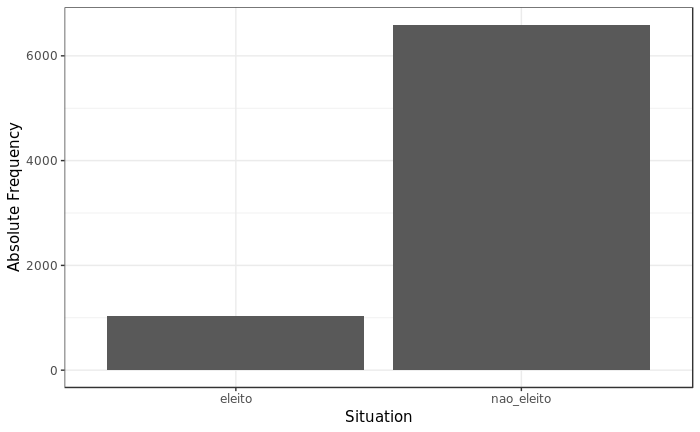

```r
data %>%
  ggplot(aes(situacao)) +
  geom_bar() +
  labs(x="Situation", y="Absolute Frequency")
```

```r
data %>%
  group_by(situacao) %>%
  summarise(num = n()) %>%
  ungroup() %>%
  mutate(total = sum(num),
         proportion = num/total)
```

| situacao | num | total | proportion |
| --- | --- | --- | --- |
| eleito | 1026 | 7622 | 0.1346103 |
| nao_eleito | 6596 | 7622 | 0.8653897 |

#### There’s a strong imbalance in the class distribution of the dataset with around 13% of the entries in the class “eleito” (elected).

- This imbalance can lead to a bias in the model that will learn to overlook the less frequent classes. Such bias can have a negative impact in the model generalization and its performance.
  - We can restore balance by removing instances from the most frequent class $undersampling$.
  - We can restore balance by adding instances from the most frequent class $oversampling$.

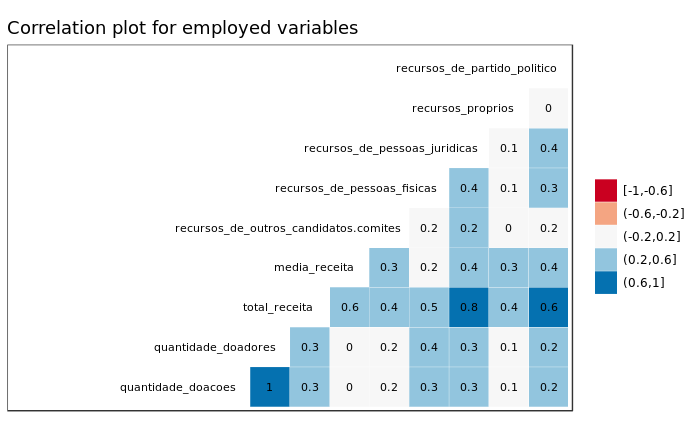

```r
data %>%
  select(-ano,
         -sequencial_candidato,
         -nome) %>%
  select(
    quantidade_doacoes,
    quantidade_doadores,
    total_receita,
    media_receita,
    recursos_de_outros_candidatos.comites,
    recursos_de_pessoas_fisicas,
    recursos_de_pessoas_juridicas,
    recursos_proprios,
    `recursos_de_partido_politico`) %>%
  na.omit() %>%
  ggcorr(palette = "RdBu", label = TRUE,
       hjust = 0.95, label_size = 3,size = 3,
       nbreaks = 5, layout.exp = 5) +
  ggtitle("Correlation plot for employed variables")
```

- Predictors such as quantidade_doacoes (Number of Donations) and quantidade_doadores (Number of Donors) are highly correlated and therefore redundant.

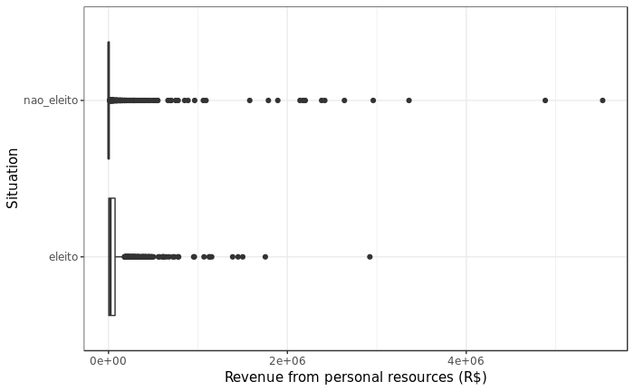

```r
data %>%
  ggplot(aes(situacao,recursos_proprios)) +
  geom_boxplot() +
  coord_flip() +
  labs(y="Revenue from personal resources (R$)", x="Situation")
```

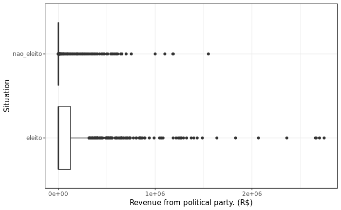

```r
data %>%
  ggplot(aes(situacao,
             recursos_de_partido_politico)) +
  geom_boxplot() +
  coord_flip() +
  labs(y="Revenue from political party. (R$)", x="Situation")
```

- Candidates who were elected had overall more revenue form their political party

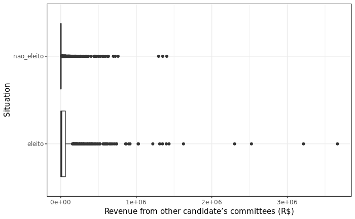

```r
data %>%
  ggplot(aes(situacao,
             recursos_de_outros_candidatos.comites)) +
  geom_boxplot() +
  coord_flip() +
  labs(y="Revenue from other candidate’s committees (R$)", x="Situation")
```

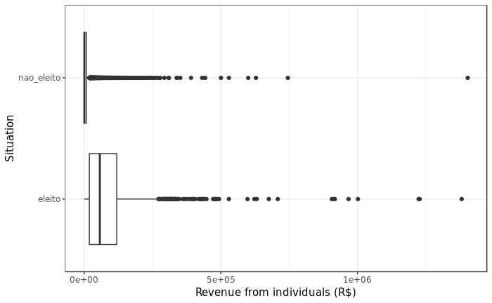

```r
data %>%
  ggplot(aes(situacao,
             recursos_de_pessoas_fisicas)) +
  geom_boxplot() +
  coord_flip() +
  labs(y="Revenue from individuals (R$)", x="Situation")
```

- Candidates who were elected had overall more revenue form individuals.

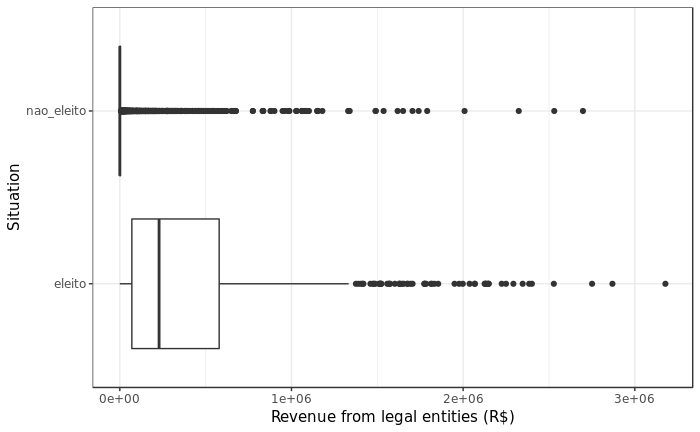

```r
data %>%
  ggplot(aes(situacao,
             recursos_de_pessoas_juridicas)) +
  geom_boxplot() +
  coord_flip() +
  labs(y="Revenue from legal entities (R$)", x="Situation")
```

- Financial support from legal entities (such as companies) seems to have been a game changer on whether a candidate was elected or not.

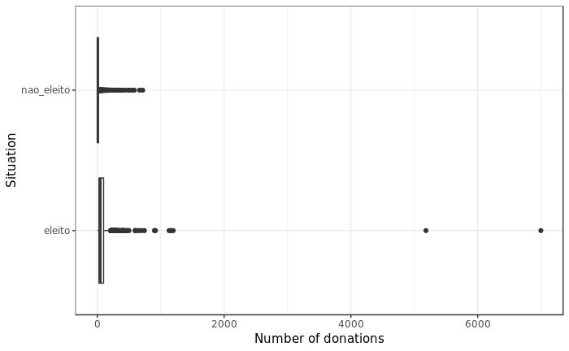

```r
data %>%
  ggplot(aes(situacao,
             quantidade_doacoes)) +
  geom_boxplot() +
  coord_flip() +
  labs(y="Number of donations", x="Situation")
```

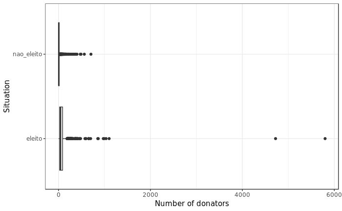

```r
data %>%
  ggplot(aes(situacao,
             quantidade_doadores)) +
  geom_boxplot() +
  coord_flip() +
  labs(y="Number of donators", x="Situation")
```

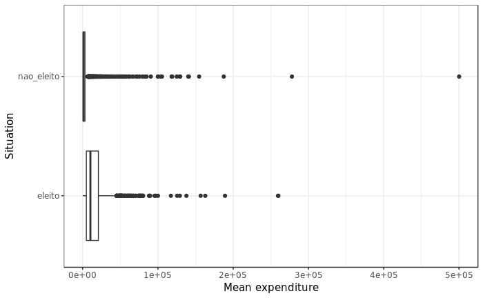

```r
data %>%
  ggplot(aes(situacao,
             media_receita)) +
  geom_boxplot() +
  coord_flip() +
  labs(y="Mean expenditure", x="Situation")
```

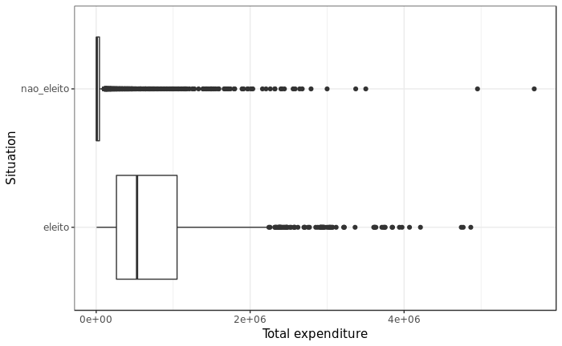

```r
data %>%
  ggplot(aes(situacao,
             total_receita)) +
  geom_boxplot() +
  coord_flip() +
  labs(y="Total expenditure", x="Situation")
```

- Who got elected spent a lot more, once again money seems to be the real gatekeeper.

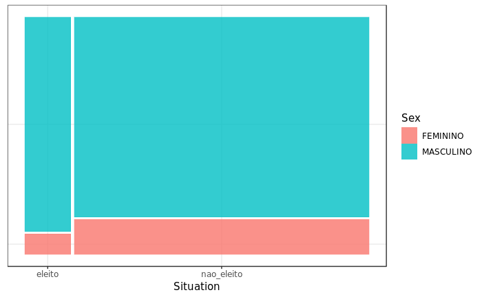

```r
data %>%
ggplot() +
   geom_mosaic(aes(x = product(sexo, situacao),
                   fill=sexo)) +
   theme(axis.title.y=element_blank(),
        axis.text.y=element_blank(),
        axis.ticks.y=element_blank()) +
  guides(fill = guide_legend(title = "Sex"))  +
  labs(x="Situation")
```

- Relatively, we see more men being elected.

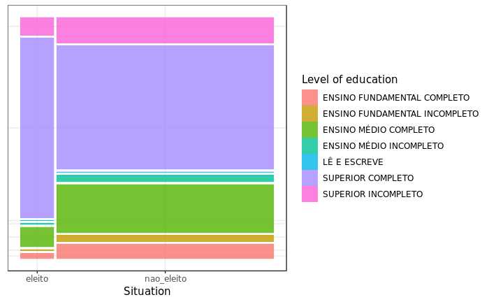

```r
data %>%
ggplot() +
  geom_mosaic(aes(x = product(grau, situacao),
                   fill=grau)) +
  theme(axis.title.y=element_blank(),
        axis.text.y=element_blank(),
        axis.ticks.y=element_blank()) +
  guides(fill = guide_legend(title = "Level of education"))  +
  labs(x="Situation")
```

- Those with a better level of education seem to have had the upper hand in the elections.

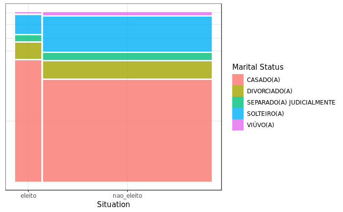

```r
data %>%
ggplot() +
   geom_mosaic(aes(x = product(estado_civil, situacao),
                   fill=estado_civil)) +
   theme(axis.title.y=element_blank(),
        axis.text.y=element_blank(),
        axis.ticks.y=element_blank()) +
  guides(fill = guide_legend(title = "Marital Status"))  +
  labs(x="Situation")
```

- Relatively, married people are more likely to be elected in this group.

## Preparing data

### Splitting data

```r
set.seed(107)
data$id <- 1:nrow(data)
data %>%
  dplyr::sample_frac(.8) -> train
cat("#### Train Shape",
    "\n##### Observations: ",nrow(train),
    "\n##### Variables: ",ncol(train))
```

```
#### Train Shape
##### Observations:  6098
##### Variables:  25
```

```r
dplyr::anti_join(data,
                 train,
                 by = 'id') -> test
cat("#### Test Shape",
    "\n##### Observations: ",nrow(test),
    "\n##### Variables: ",ncol(test))
```

```
#### Test Shape
##### Observations:  1524
##### Variables:  25
```

```r
train %>%
    select(-ano,-nome,-id,-sequencial_candidato) -> train
test %>%
    select(-ano,-nome,-id,-sequencial_candidato) -> test
```

```r
train %>%
  dplyr::select_if(.,is.numeric) -> train.numeric
train %>%
  dplyr::select_if(.,negate(is.numeric)) -> train.categorical
test %>%
  dplyr::select_if(.,is.numeric) -> test.numeric
test %>%
  dplyr::select_if(.,negate(is.numeric)) -> test.categorical
```

### Scale and Center

```r
train.numeric %>%
  preProcess(.,method = c("center","scale")) -> processParams
processParams %>%
  predict(.,train.numeric) -> train.numeric
processParams %>%
  predict(.,test.numeric) -> test.numeric
processParams
```

```
Created from 6098 samples and 13 variables

Pre-processing:
  - centered (13)
  - ignored (0)
  - scaled (13)
```

### One Hot Encoding

```r
train.numeric %>%
  dplyr::bind_cols(train.categorical) -> train
test.numeric %>%
  dplyr::bind_cols(test.categorical) -> test
```

```r
encoding <- build_encoding(dataSet = train,
                          cols = c("uf","sexo","grau","ocupacao",
                                   "partido","estado_civil"),
                          verbose = F)
train <- one_hot_encoder(dataSet = train,
                          encoding = encoding,
                          drop = TRUE,
                          verbose = F)
cat("#### Train Shape",
    "\n##### Observations: ",nrow(train),
    "\n##### Variables: ",ncol(train))
```

#### Train Shape

##### Observations: 6098

##### Variables: 263

```r
test <- one_hot_encoder(dataSet = test,
                          encoding = encoding,
                          drop = TRUE,
                          verbose = F)
cat("#### Data Shape",
    "\n##### Observations: ",nrow(test),
    "\n##### Variables: ",ncol(test))
```

```
#### Data Shape
##### Observations:  1524
##### Variables:  263
```

### Near Zero Variance Predictors

```r
train %>%
  nearZeroVar(saveMetrics = TRUE) %>%
  tibble::rownames_to_column("variable") %>%
  filter(nzv == T) %>%
  pull(variable) -> near_zero_vars
train %>%
    select(-one_of(near_zero_vars)) -> train
test %>%
    select(-one_of(near_zero_vars)) -> test
near_zero_vars %>%
  glimpse()
```

```
 chr [1:224] "cargo" "uf.AC" "uf.AL" "uf.AM" "uf.AP" "uf.BA" "uf.CE" "uf.DF" "uf.ES" "uf.GO" "uf.MA" "uf.MS" "uf.MT" "uf.PA" "uf.PB" "uf.PE" "uf.PI" "uf.RN" "uf.RO" ...
```

# Unbalanced dataset

- In this section we shall test the candidate models without applying any sort of undersampling or oversampling to the employed data

## Logistic Regression

```r
f1 <- function(data, lev = NULL, model = NULL) {
  f1_val <- F1_Score(y_pred = data$pred,
                     y_true = data$obs,
                     positive = lev[1])
  c(F1 = f1_val)
}
F_Measure <- function(expected, predicted, ...) {
  data.frame(expected=expected,
             prediction=predicted) %>%
      mutate(TP = ifelse(expected == "eleito" &
                         prediction == "eleito",1,0),
             TN = ifelse(expected == "nao_eleito" &
                         prediction == "nao_eleito",1,0),
             FN = ifelse(expected == "eleito" &
                         prediction == "nao_eleito",1,0),
             FP = ifelse(expected == "nao_eleito" &
                         prediction == "eleito",1,0)) -> result
  result  %>%
    summarize(TP = sum(TP),
              TN = sum(TN),
              FP = sum(FP),
              FN = sum(FN)) %>%
    mutate(recall = TP / (TP + FN),
           precision = TP / (TP + FP),
           accuracy = (TP + TN)/(TP + TN + FP + FN),
           f_measure = 2 * (precision * recall) / (precision + recall)) -> result

  return(result)
}
```

```r
rlGrid <- expand.grid( cost = c(200,2,0.02),
                       loss = c("L1", "L2_dual", "L2_primal"),
                       epsilon = c(0.001,0.01) )
train %>%
  caret::train(situacao ~ .,
               data= .,
               method = "regLogistic",
               metric = "F1",
               trControl = trainControl(method = "boot",
                                        classProbs = TRUE,
                                        summaryFunction = f1,
                                        savePredictions = "final"),
               tuneGrid = rlGrid) -> model.rl
```

```r
model.rl
```

```
Regularized Logistic Regression

6098 samples
  38 predictors
   2 classes: 'eleito', 'nao_eleito'

No pre-processing
Resampling: Bootstrapped (25 reps)
Summary of sample sizes: 6098, 6098, 6098, 6098, 6098, 6098, ...
Resampling results across tuning parameters:

  cost   loss       epsilon  F1
  2e-02  L1         0.001    0.5841929
  2e-02  L1         0.010    0.5850193
  2e-02  L2_dual    0.001    0.5994658
  2e-02  L2_dual    0.010    0.5994658
  2e-02  L2_primal  0.001    0.5994150
  2e-02  L2_primal  0.010    0.6000753
  2e+00  L1         0.001    0.6342838
  2e+00  L1         0.010    0.6359184
  2e+00  L2_dual    0.001    0.6333125
  2e+00  L2_dual    0.010    0.6333125
  2e+00  L2_primal  0.001    0.6332243
  2e+00  L2_primal  0.010    0.6335837
  2e+02  L1         0.001    0.6329757
  2e+02  L1         0.010    0.6355253
  2e+02  L2_dual    0.001    0.6445493
  2e+02  L2_dual    0.010    0.6487011
  2e+02  L2_primal  0.001    0.6330532
  2e+02  L2_primal  0.010    0.6344372

F1 was used to select the optimal model using the largest value.
The final values used for the model were cost = 200, loss = L2_dual and epsilon = 0.01.
```

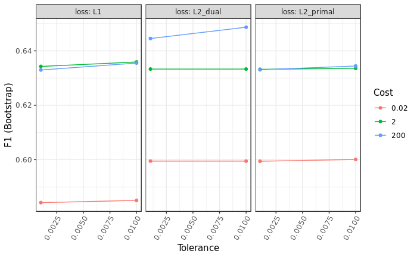

```r
model.rl %$%
  results %>%
  mutate(cost=as.factor(cost)) %>%
  ggplot(aes(epsilon,F1,
             color=cost)) +
  geom_line() +
  geom_point() +
  labs(y= "F1 (Bootstrap)", x="Tolerance") +
  facet_wrap(. ~ loss, labeller = "label_both") +
  guides(color = guide_legend(title = "Cost")) +
  theme(axis.text.x = element_text(angle = 60, hjust = 1))
```

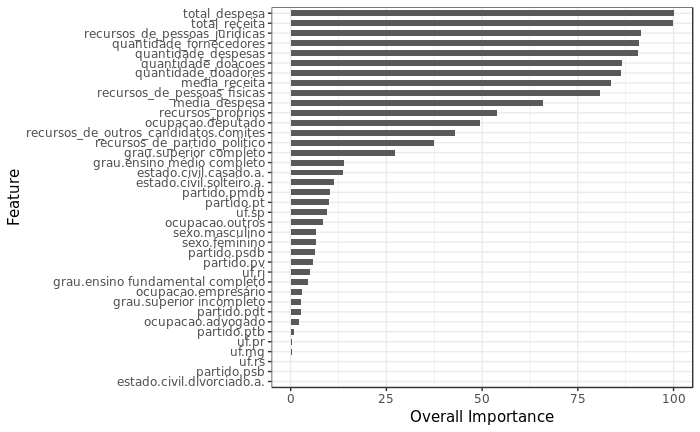

```r
model.rl %>%
  varImp() %$%
  importance %>%
  as.data.frame() %>%
  rownames_to_column(var="Feature") %>%
  mutate(Feature = tolower(Feature)) %>%
  ggplot() +
  geom_col(aes(x = reorder(Feature,eleito),y = eleito),
           position = position_dodge(width=0.8),width=0.6) +
  labs(x="Feature", y="Overall Importance") +
  coord_flip()
```

- **Total Receita** (Total Revenue), **Total Despesa** (Total Expenditure) and **Recursos de pessoas jurídicas** (Revenue from Legal Entities) are together the three most important features in the model.
- Despite regularization a lot of features were employed, however many were considered less important.

### Quality metric

#### Train and Validation

```r
model.rl %$%
  pred %>%
  F_Measure(expected = .$obs,
            predicted = .$pred)
```

| TP | TN | FP | FN | recall | precision | accuracy | f_measure |
| --- | --- | --- | --- | --- | --- | --- | --- |
| 4462 | 46905 | 1807 | 3006 | 0.5974826 | 0.7117563 | 0.9143289 | 0.6496324 |

- A decent although uninspiring result.

#### Test

```r
test %>%
  select(-situacao) %>%
  predict(object=model.rl,.) %>%
  F_Measure(test$situacao,.)
```

| TP | TN | FP | FN | recall | precision | accuracy | f_measure |
| --- | --- | --- | --- | --- | --- | --- | --- |
| 115 | 1268 | 43 | 98 | 0.5399061 | 0.7278481 | 0.9074803 | 0.6199461 |

- The test result is rather close to the train/validation results, this is a good sign. However, the model results are not particularly promising.

## K nearest neighbours

```r
neighborsGrid <- expand.grid(.k = seq(from=1, to=50, by=1))

train %>%
  train(situacao ~ .,
        data = .,
        metric = "F1",
        method = "knn",
        na.action = na.omit,
        tuneGrid = neighborsGrid,
        trControl = trainControl(method = "boot",
                                 classProbs = TRUE,
                                 summaryFunction = f1,
                                 savePredictions = "final")) -> model.knn
```

```r
model.knn
```

```
k-Nearest Neighbors

6098 samples
  38 predictors
   2 classes: 'eleito', 'nao_eleito'

No pre-processing
Resampling: Bootstrapped (25 reps)
Summary of sample sizes: 6098, 6098, 6098, 6098, 6098, 6098, ...
Resampling results across tuning parameters:

  k   F1
   1  0.5824759
   2  0.5875895
   3  0.6007862
```

[output cut: 50 more lines]

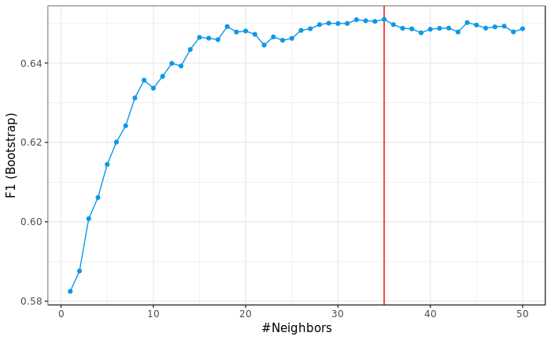

```r
model.knn %$%
  bestTune %$%
  k -> bestParameter
model.knn %$%
  results %>%
  ggplot(aes(k,F1)) +
  geom_vline(xintercept = bestParameter,
             color = "red") +
  geom_point(color="#0D98E8") +
  geom_line(color="#0D98E8") +
  labs(x="#Neighbors",
       y="F1 (Bootstrap)")
```

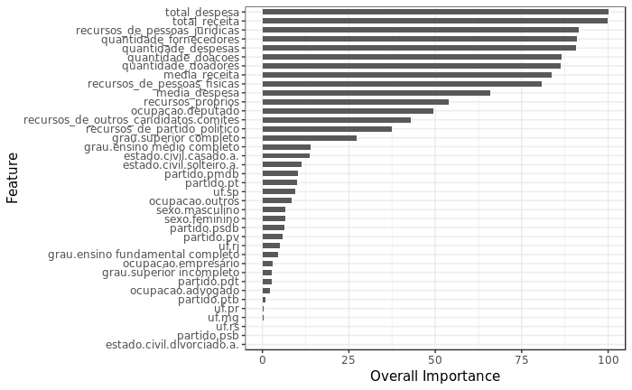

```r
model.knn %>%
  varImp() %$%
  importance %>%
  as.data.frame() %>%
  rownames_to_column(var="Feature") %>%
  mutate(Feature = tolower(Feature)) %>%
  ggplot() +
  geom_col(aes(x = reorder(Feature,eleito),y = eleito),
           position = position_dodge(width=0.8),width=0.6) +
  labs(x="Feature", y="Overall Importance") +
  coord_flip()
```

- **Total Receita** (Total Revenue), **Total Despesa** (Total Expenditure) and **Recursos de pessoas jurídicas** (Revenue from Legal Entities) are together the three most important features in this model as well.
- The KNN algorithm made use of almost all predictors, this may be a bad sign.

### Quality metric

#### Train and Validation

```r
model.knn %$%
  pred %>%
  F_Measure(expected = .$obs,
            predicted = .$pred)
```

| TP | TN | FP | FN | recall | precision | accuracy | f_measure |
| --- | --- | --- | --- | --- | --- | --- | --- |
| 4533 | 46832 | 2009 | 2845 | 0.6143941 | 0.6929074 | 0.9136591 | 0.6512931 |

- Here we have slightly better results than those of the Logistic Regression.

#### Test

```r
test %>%
  select(-situacao) %>%
  predict(object=model.knn,.) %>%
  F_Measure(test$situacao,.)
```

| TP | TN | FP | FN | recall | precision | accuracy | f_measure |
| --- | --- | --- | --- | --- | --- | --- | --- |
| 122 | 1259 | 52 | 91 | 0.57277 | 0.7011494 | 0.906168 | 0.630491 |

- We have modest results, but they are consonant with those from train/test.
  - This suggests that the KNN model may be too simple for this particular instance, and bias would be the predominant component in the model error.

## Decision Tree

```r
rpart.grid <- expand.grid(.cp = seq(from=0, to=0.1, by=0.005))

caret::train(x = select(train, -situacao),
             y = train$situacao,
             metric = "F1",
             method = "rpart",
             na.action = na.omit,
             tuneGrid = rpart.grid,
             trControl = trainControl(method = "boot",
                                      classProbs = TRUE,
                                      summaryFunction = f1,
                                      savePredictions = "final")) -> model.tree
```

```r
model.tree
```

```
CART

6098 samples
  38 predictors
   2 classes: 'eleito', 'nao_eleito'

No pre-processing
Resampling: Bootstrapped (25 reps)
Summary of sample sizes: 6098, 6098, 6098, 6098, 6098, 6098, ...
Resampling results across tuning parameters:

  cp     F1
  0.000  0.6222605
  0.005  0.6597754
  0.010  0.6730765
  0.015  0.6737400
  0.020  0.6684035
  0.025  0.6684085
  0.030  0.6668214
  0.035  0.6681258
  0.040  0.6681258
  0.045  0.6681258
  0.050  0.6661671
  0.055  0.6661671
  0.060  0.6712018
  0.065  0.6699034
  0.070  0.6700850
  0.075  0.6702300
  0.080  0.6717618
  0.085  0.6726706
  0.090  0.6632295
  0.095  0.6726590
  0.100  0.6660222

F1 was used to select the optimal model using the largest value.
The final value used for the model was cp = 0.015.
```

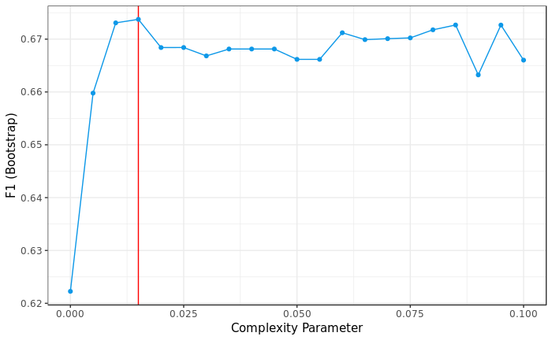

```r
model.tree %$%
  bestTune %$%
  cp -> bestParameter
model.tree %$%
  results %>%
  ggplot(aes(cp,F1)) +
  geom_vline(xintercept = bestParameter,
             color = "red") +
  geom_point(color="#0D98E8") +
  geom_line(color="#0D98E8") +
  labs(x="Complexity Parameter",
       y="F1 (Bootstrap)")
```

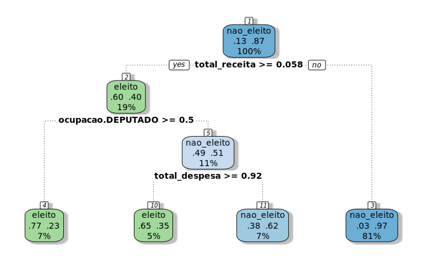

```r
model.tree %$%
  finalModel %>%
  fancyRpartPlot(sub="")
```

- The best performing tree seems simple yet reasonable.
  - This tree may be in the border of an underfitting.

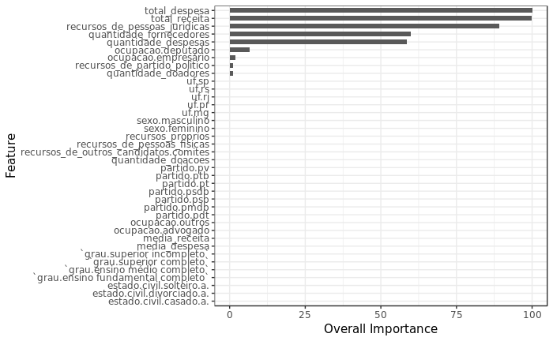

```r
model.tree %>%
  varImp() %$%
  importance %>%
  as.data.frame() %>%
  rownames_to_column(var="Feature") %>%
  mutate(Feature = tolower(Feature)) %>%
  ggplot() +
  geom_col(aes(x = reorder(Feature,Overall),y = Overall),
           position = position_dodge(width=0.8),width=0.6) +
  labs(x="Feature", y="Overall Importance") +
  coord_flip()
```

- **Total Receita** (Total Revenue), **Total Despesa** (Total Expenditure) and **Recursos de pessoas jurídicas** (Revenue from Legal Entities) are together the three most important features in this model as well.
- The tree used very few predictors which may indicate an underfitting, or simply that the tree captured the few meaningful predictors.

### Quality metric

#### Train and Validation

```r
model.tree %$%
  pred %>%
  F_Measure(expected = .$obs,
            predicted = .$pred)
```

| TP | TN | FP | FN | recall | precision | accuracy | f_measure |
| --- | --- | --- | --- | --- | --- | --- | --- |
| 4922 | 46495 | 2084 | 2667 | 0.6485703 | 0.7025407 | 0.9154145 | 0.6744776 |

- Here we have surprisingly good results considering the simplicity of the tree.

### Test

```r
test %>%
  select(-situacao) %>%
  predict(object=model.tree,.) %>%
  F_Measure(test$situacao,.)
```

| TP | TN | FP | FN | recall | precision | accuracy | f_measure |
| --- | --- | --- | --- | --- | --- | --- | --- |
| 128 | 1252 | 59 | 85 | 0.600939 | 0.684492 | 0.9055118 | 0.64 |

- We have slightly better results than those seen till now, on top of that they are consonant with those from train/test.

## AdaBoost

```r
train(x = select(train, -situacao),
      y = train$situacao,
      metric = "F1",
      na.action = na.exclude,
      method='adaboost',
      tuneLength=2,
      trControl = trainControl(savePredictions = "final",
                               summaryFunction = f1,
                               classProbs = TRUE,
                               method = "boot")) -> model.ada
```

```r
model.ada
```

[output not shown]

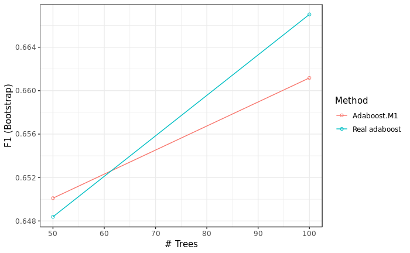

```r
model.ada %$%
  results %>%
  ggplot(aes(nIter,F1,
             color=as.factor(method))) +
  geom_point(shape=1) +
  geom_line() +
  labs(x="# Trees",y="F1 (Bootstrap)") +
  guides(color = guide_legend(title = "Method"))
```

### Train and Validation

```r
model.ada %$%
  pred %>%
  F_Measure(expected = .$obs,
            predicted = .$pred)
```

| TP | TN | FP | FN | recall | precision | accuracy | f_measure |
| --- | --- | --- | --- | --- | --- | --- | --- |
| 529 | 5041 | 244 | 284 | 0.6506765 | 0.6843467 | 0.9134142 | 0.667087 |

### Test

```r
test %>%
  select(-situacao) %>%
  predict(object=model.ada,.) %>%
  F_Measure(test$situacao,.)
```

[output not shown]

- The loss in the quality metric going from train/validation to test was small enough.
- This suggest that the model did in fact fit the behavior of the problem and not noise.

# Applying Oversample (SMOTE)

```r
train %>%
  SMOTE(situacao ~ .,
        data = .,
        perc.over = 200,
        perc.under=200) -> oversampled
cat("#### Train Shape",
    "\n##### Observations: ",nrow(oversampled),
    "\n##### Variables: ",ncol(oversampled))
```

```
#### Train Shape
##### Observations:  5691
##### Variables:  39
```

```r
oversampled %>%
  group_by(situacao) %>%
  summarise(num = n()) %>%
  ungroup() %>%
  mutate(total = sum(num),
         proportion = num/total)
```

| situacao | num | total | proportion |
| --- | --- | --- | --- |
| eleito | 2439 | 5691 | 0.4285714 |
| nao_eleito | 3252 | 5691 | 0.5714286 |

- BY means of SMOTE we have reduce the class imbalance considerably

## Logistic Regression with SMOTE

```r
rlGrid <- expand.grid( cost = c(0.02,0.1,2,20,100,200),
                       loss = c("L1", "L2_dual", "L2_primal"),
                       epsilon = seq(from=0.001,to=0.1, by=0.005) )
oversampled %>%
  caret::train(situacao ~ .,
               data= .,
               method = "regLogistic",
               metric = "F1",
               trControl = trainControl(method = "boot",
                                        classProbs = TRUE,
                                        summaryFunction = f1,
                                        savePredictions = "final"),
               tuneGrid = rlGrid) -> model.rl.smote
```

```r
model.rl.smote
```

```
Regularized Logistic Regression

5691 samples
  38 predictors
   2 classes: 'eleito', 'nao_eleito'

No pre-processing
Resampling: Bootstrapped (25 reps)
Summary of sample sizes: 5691, 5691, 5691, 5691, 5691, 5691, ...
Resampling results across tuning parameters:

  cost   loss       epsilon  F1
  2e-02  L1         0.001    0.8538309
  2e-02  L1         0.006    0.8540300
  2e-02  L1         0.011    0.8553297
  2e-02  L1         0.016    0.8553614
  2e-02  L1         0.021    0.8550155
  2e-02  L1         0.026    0.8554397
  2e-02  L1         0.031    0.8548420
  2e-02  L1         0.036    0.8535600
  2e-02  L1         0.041    0.8549967
  2e-02  L1         0.046    0.8540555
  2e-02  L1         0.051    0.8539844
  2e-02  L1         0.056    0.8542698
  2e-02  L1         0.061    0.8541436
  2e-02  L1         0.066    0.8539469
  2e-02  L1         0.071    0.8531028
  2e-02  L1         0.076    0.8503106
  2e-02  L1         0.081    0.8526496
  2e-02  L1         0.086    0.8501218
  2e-02  L1         0.091    0.8469466
  2e-02  L1         0.096    0.8481336
  2e-02  L2_dual    0.001    0.8536869
  2e-02  L2_dual    0.006    0.8536869
  2e-02  L2_dual    0.011    0.8536869
  2e-02  L2_dual    0.016    0.8536869
  2e-02  L2_dual    0.021    0.8536869
  2e-02  L2_dual    0.026    0.8536604
  2e-02  L2_dual    0.031    0.8536863
  2e-02  L2_dual    0.036    0.8536604
```

[output cut: 211 more lines]

```
  2e+01  L2_primal  0.096    0.8610384
  1e+02  L1         0.001    0.8634602
  1e+02  L1         0.006    0.8623150
  1e+02  L1         0.011    0.8610625
  1e+02  L1         0.016    0.8604169
  1e+02  L1         0.021    0.8586845
  1e+02  L1         0.026    0.8588839
  1e+02  L1         0.031    0.8584691
  1e+02  L1         0.036    0.8581030
  1e+02  L1         0.041    0.8569379
  1e+02  L1         0.046    0.8561318
 [ reached getOption("max.print") -- omitted 110 rows ]

F1 was used to select the optimal model using the largest value.
The final values used for the model were cost = 200, loss = L2_dual and epsilon = 0.051.
```

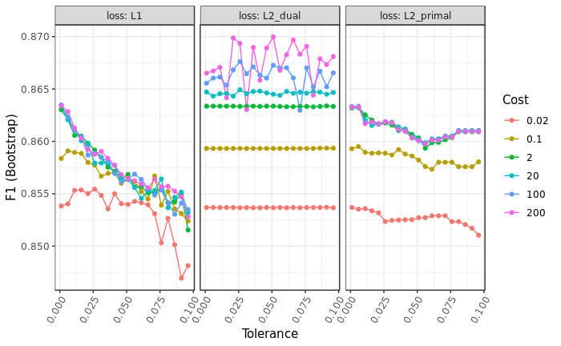

```r
model.rl.smote %$%
  results %>%
  mutate(cost=as.factor(cost)) %>%
  ggplot(aes(epsilon,F1,
             color=cost)) +
  geom_line() +
  geom_point() +
  labs(y= "F1 (Bootstrap)", x="Tolerance") +
  facet_wrap(. ~ loss, labeller = "label_both") +
  guides(color = guide_legend(title = "Cost")) +
  theme(axis.text.x = element_text(angle = 60, hjust = 1))
```

- The hyper-parameter **Loss** seems to be the particularly meaningful for the Logistic Regression performance in this problem.

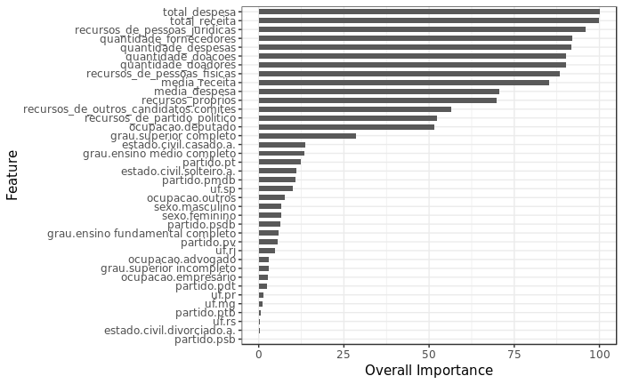

```r
model.rl.smote %>%
  varImp() %$%
  importance %>%
  as.data.frame() %>%
  rownames_to_column(var="Feature") %>%
  mutate(Feature = tolower(Feature)) %>%
  ggplot() +
  geom_col(aes(x = reorder(Feature,eleito),y = eleito),
           position = position_dodge(width=0.8),width=0.6) +
  labs(x="Feature", y="Overall Importance") +
  coord_flip()
```

- **Total Receita** (Total Revenue), **Total Despesa** (Total Expenditure) and **Recursos de pessoas jurídicas** (Revenue from Legal Entities) are together the three most important features in this model as well.
- Despite regularization a lot of features were employed, however many were considered less important.

### Quality metric

#### Train and Validation

```r
model.rl.smote %$%
  pred %>%
  F_Measure(expected = .$obs,
            predicted = .$pred)
```

| TP | TN | FP | FN | recall | precision | accuracy | f_measure |
| --- | --- | --- | --- | --- | --- | --- | --- |
| 19179 | 27371 | 2493 | 3238 | 0.8555561 | 0.8849668 | 0.8903808 | 0.8700129 |

- The results in train/validation are overly optimistic in reason of the imbalance correction and should not be taken seriously.
- Actual progress shall be assessed in the test stage

#### Test

```r
test %>%
  select(-situacao) %>%
  predict(object=model.rl.smote,.) %>%
  F_Measure(test$situacao,.)
```

| TP | TN | FP | FN | recall | precision | accuracy | f_measure |
| --- | --- | --- | --- | --- | --- | --- | --- |
| 175 | 1199 | 112 | 38 | 0.8215962 | 0.6097561 | 0.9015748 | 0.7 |

- We can see a substantial improvement compared with our previous attempt using Logistic Regression.

## K nearest neighbours with SMOTE

```r
neighborsGrid <- expand.grid(.k = seq(from=1, to=50, by=1))

oversampled %>%
  train(situacao ~ .,
        data = .,
        metric = "F1",
        method = "knn",
        na.action = na.omit,
        tuneGrid = neighborsGrid,
        trControl = trainControl(method = "boot",
                                 classProbs = TRUE,
                                 summaryFunction = f1,
                                 savePredictions = "final")) -> model.knn.smote
```

```r
model.knn.smote
```

```
k-Nearest Neighbors

5691 samples
  38 predictors
   2 classes: 'eleito', 'nao_eleito'

No pre-processing
Resampling: Bootstrapped (25 reps)
Summary of sample sizes: 5691, 5691, 5691, 5691, 5691, 5691, ...
Resampling results across tuning parameters:

  k   F1
   1  0.9321092
   2  0.9132311
   3  0.9049864
```

[output cut: 50 more lines]

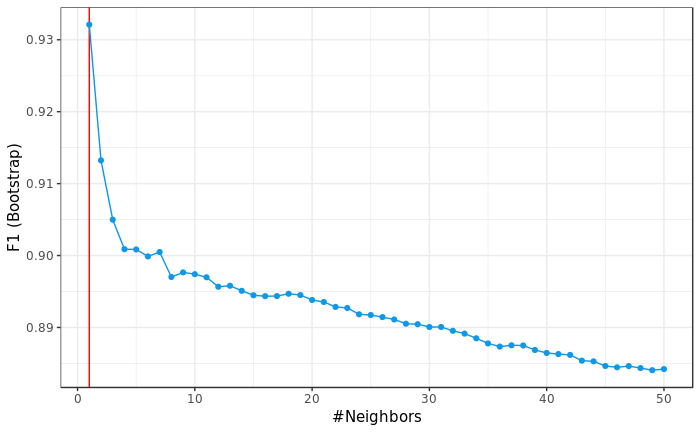

```r
model.knn.smote %$%
  bestTune %$%
  k -> bestParameter
model.knn.smote %$%
  results %>%
  ggplot(aes(k,F1)) +
  geom_vline(xintercept = bestParameter,
             color = "red") +
  geom_point(color="#0D98E8") +
  geom_line(color="#0D98E8") +
  labs(x="#Neighbors",
       y="F1 (Bootstrap)")
```

- Our cross validation led to a knn with K=1, this may hint at a overfitting.

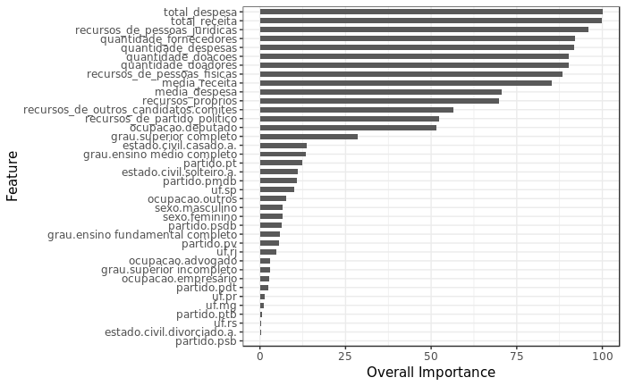

- **Total Receita** (Total Revenue), **Total Despesa** (Total Expenditure) and **Recursos de pessoas jurídicas** (Revenue from Legal Entities) are together the three most important features in this model as well.

### Quality metric

#### Train and Validation

| TP | TN | FP | FN | recall | precision | accuracy | f_measure |
| --- | --- | --- | --- | --- | --- | --- | --- |
| 21479 | 27701 | 2211 | 919 | 0.9589696 | 0.9066695 | 0.9401644 | 0.9320864 |

- The results in train/validation are overly optimistic in reason of the imbalance correction and should not be taken seriously.
- We have train/validation results incredibly good, in fact too good.
  - This adds up to the hypothesis of a overfitting.

#### Test

| TP | TN | FP | FN | recall | precision | accuracy | f_measure |
| --- | --- | --- | --- | --- | --- | --- | --- |
| 158 | 1197 | 114 | 55 | 0.741784 | 0.5808824 | 0.8891076 | 0.6515464 |

- And here we have a **steep** decline in the test results, this is clear evidence that our KNN plus SMOTE overfitted.

## Decision Tree with SMOTE

```r
rpart.grid <- expand.grid(.cp = seq(from=0, to=0.1, by=0.005))

caret::train(x = select(oversampled, -situacao),
             y = oversampled$situacao,
             metric = "F1",
             method = "rpart",
             na.action = na.omit,
             tuneGrid = rpart.grid,
             trControl = trainControl(method = "boot",
                                      classProbs = TRUE,
                                      summaryFunction = f1,
                                      savePredictions = "final")) -> model.tree.smote
```

```r
model.tree.smote
```

```
CART

5691 samples
  38 predictors
   2 classes: 'eleito', 'nao_eleito'

No pre-processing
Resampling: Bootstrapped (25 reps)
Summary of sample sizes: 5691, 5691, 5691, 5691, 5691, 5691, ...
Resampling results across tuning parameters:

  cp     F1
  0.000  0.8861902
  0.005  0.8959433
  0.010  0.8942471
  0.015  0.8901458
  0.020  0.8901458
  0.025  0.8901458
  0.030  0.8901458
  0.035  0.8901458
  0.040  0.8901458
  0.045  0.8901458
  0.050  0.8901458
  0.055  0.8901458
  0.060  0.8901458
  0.065  0.8901458
  0.070  0.8901458
  0.075  0.8901458
  0.080  0.8901458
  0.085  0.8901458
  0.090  0.8901458
  0.095  0.8901458
  0.100  0.8901458

F1 was used to select the optimal model using the largest value.
The final value used for the model was cp = 0.005.
```

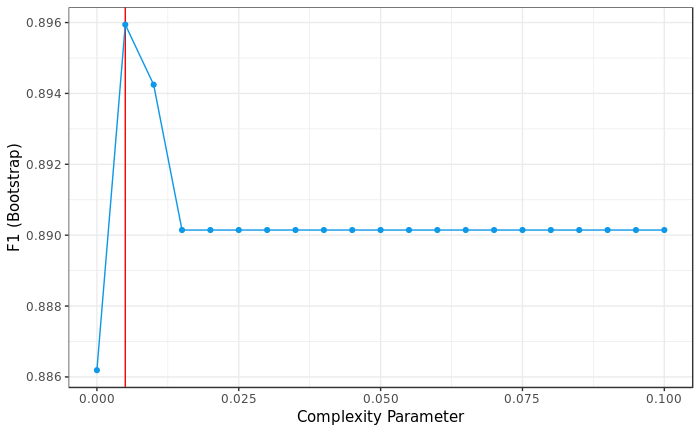

```r
model.tree.smote %$%
  bestTune %$%
  cp -> bestParameter
model.tree.smote %$%
  results %>%
  ggplot(aes(cp,F1)) +
  geom_vline(xintercept = bestParameter,
             color = "red") +
  geom_point(color="#0D98E8") +
  geom_line(color="#0D98E8") +
  labs(x="Complexity Parameter",
       y="F1 (Bootstrap)")
```

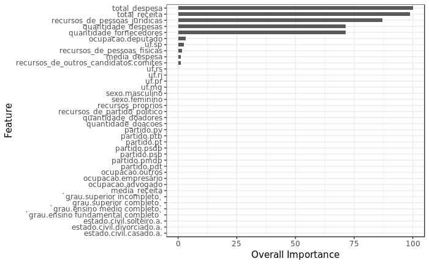

- **Total Receita** (Total Revenue), **Total Despesa** (Total Expenditure) and **Recursos de pessoas jurídicas** (Revenue from Legal Entities) are together the three most important features in this model as well.

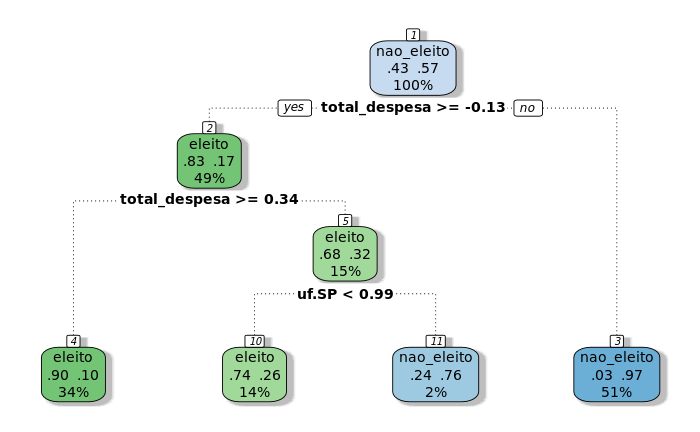

### Quality metric

#### Train and Validation

| TP | TN | FP | FN | recall | precision | accuracy | f_measure |
| --- | --- | --- | --- | --- | --- | --- | --- |
| 20964 | 26408 | 3523 | 1342 | 0.9398368 | 0.8561277 | 0.9068668 | 0.8960315 |

- The results in train/validation are overly optimistic in reason of the imbalance correction and should not be taken seriously.

#### Test

| TP | TN | FP | FN | recall | precision | accuracy | f_measure |
| --- | --- | --- | --- | --- | --- | --- | --- |
| 192 | 1166 | 145 | 21 | 0.9014085 | 0.5697329 | 0.8910761 | 0.6981818 |

- A result similar to that of the Logistic Regression plus SMOTE

## AdaBoost with SMOTE

```r
train(x = select(oversampled, -situacao),
      y = oversampled$situacao,
      metric = "F1",
      na.action = na.exclude,
      method='adaboost',
      tuneLength=2,
      trControl = trainControl(savePredictions = "final",
                               summaryFunction = f1,
                               classProbs = TRUE,
                               method = "boot")) -> model.ada.smote
```

```r
model.ada.smote
```

```
AdaBoost Classification Trees

5691 samples
  38 predictors
   2 classes: 'eleito', 'nao_eleito'

No pre-processing
Resampling: Bootstrapped (25 reps)
Summary of sample sizes: 5691, 5691, 5691, 5691, 5691, 5691, ...
Resampling results across tuning parameters:

  nIter  method         F1
   50    Adaboost.M1    0.9352572
   50    Real adaboost  0.9343263
  100    Adaboost.M1    0.9361092
  100    Real adaboost  0.9353782

F1 was used to select the optimal model using the largest value.
The final values used for the model were nIter = 100 and method = Adaboost.M1.
```

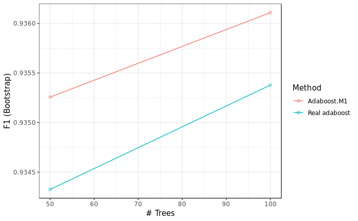

### Quality metric

#### Train and Validation

| TP | TN | FP | FN | recall | precision | accuracy | f_measure |
| --- | --- | --- | --- | --- | --- | --- | --- |
| 21509 | 27662 | 2095 | 839 | 0.9624575 | 0.9112439 | 0.9436906 | 0.9361508 |

- The results in train/validation are overly optimistic in reason of the imbalance correction and should not be taken seriously.
- Actual progress shall be assessed in the test stage

#### Test

| TP | TN | FP | FN | recall | precision | accuracy | f_measure |
| --- | --- | --- | --- | --- | --- | --- | --- |
| 181 | 1193 | 118 | 32 | 0.8497653 | 0.6053512 | 0.9015748 | 0.7070312 |

- Results similar to those of the Logistic Regression plus SMOTE